# Mission n°2

Vous réaliserez l’analyse des données.  
Une grande liberté vous est laissée sur ce plan, mais à vous de trouver les informations  
qui ont du sens pour mieux comprendre les ventes :

Vous devrez y utiliser au moins :

- des indicateurs de tendance centrale et de dispersion
- une analyse de concentration, via une courbe de Lorenz et un indice de Gini
- des représentations graphiques, dont au moins un histogramme, une représentation avec des "boites à moustaches"
- une représentation de série temporelle (c’est à dire un graphique dont l’axe des abscisses représente des dates)
- des analyses bivariées

### Table des matières

#### 1. Etude préparatoire

- Analyse du type de variables
- Analyse de 'age' et de 'price'
- Courbe le Lorenz et indice Gini de 'price'

#### 2. Analyse par sexe et par catégories

- Pourcentage hommes/femmes
- Sexe, âge et catégories
- Sexe, prix et catégories

#### 3. Produits achetés

- Répartition du prix des produits achetés par âge
- Répartition du prix des produits achetés par âge et par catégorie
- Distribution des produits achetés

#### 4. Sessions

- Nombre de sessions par âge
- Nombre de sessions par âge et par catégorie

#### 5. Chiffre d'affaires

- Répartition du chiffre d'affaires par âge
- Répartition du chiffre d'affaires par âge et par catégories

#### 6. Panier moyen

- panier moyen par âge
- panier moyen par âge et par catégories

#### 7. Séries temporelles

- Série temporelle par nombre de sessions et par catégorie
- Série temporelle par CA et par catégorie

```python
# Import des librairies
import numpy as np
import pandas as pd

import matplotlib.pyplot as plt
%matplotlib inline
from pylab import rcParams
from scipy import stats
import seaborn as sns
```

```python
# import de la table nettoyée de la question 1
table_clean = pd.read_csv('data/table_clean.csv')
table_clean.head(1)
```

|  | level_0 | index | session_id | client_id | sex | age | id_prod | price | categ | timeline | date | year | month | day | hour | timestamp |
| --- | --- | --- | --- | --- | --- | --- | --- | --- | --- | --- | --- | --- | --- | --- | --- | --- |
| 0 | 0 | 0 | s_12716 | c_6624 | m | 69.0 | 1_264 | 16.07 | 1 | 2021-03 | 28-03-2021 | 2021 | 3 | Sunday | 17 | 2021-03-28 17:16:26.325707 |

## 1. [tdm] Etude préparatoire

#### 1. [tdm] Analyse du type de variables

[figure not shown]

#### 2. [tdm] Analyse de 'age' et de 'price'

- 'age' et 'price' son les deux seules variables quantitatives du df

```python
# description de 'age' et 'price'
table_clean[['age','price']].describe()
```

|  | age | price |
| --- | --- | --- |
| count | 313651.000000 | 313651.000000 |
| mean | 44.206567 | 17.100733 |
| std | 13.797003 | 17.594521 |
| min | 18.000000 | 0.620000 |
| 25% | 35.000000 | 8.580000 |
| 50% | 43.000000 | 13.820000 |
| 75% | 51.000000 | 18.990000 |
| max | 93.000000 | 300.000000 |

- Pour 'age', la moyenne et la médiane sont très proches, 43-44 ans. L'équart inter interquartile (35-51) est de 16 ans
- Pour 'price' (prix des produits), la moyenne est plus proche du 3e quartile que de la médiane - skewness à droite. L'écart interquartile (8.6-19.0) est de 10.4

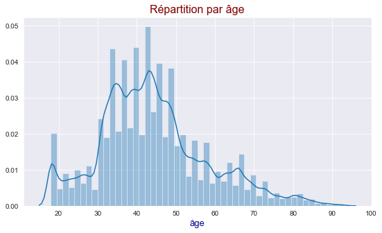

```python
# visualisation de la répartition par âge
sns.set_style("darkgrid")
plt.figure(figsize=(9,5))

# graphique
rep_age = table_clean[['age']].copy()
sns.distplot(rep_age.age)

# titre
plt.title('Répartition par âge', fontsize=16, color='maroon')
# labels
plt.xlabel('âge', color='darkblue', size=13)

plt.savefig('img/Q2/1.2 rep_age.png', dpi=120, bbox_inches='tight')
plt.show()
plt.close()
```

- Il y a des écarts suspects entre les tranches d'une même classe d'âge
- Sans doute les barres pourraient être lissées si nous disposions également du mois et du jour de naissance
- Par ailleurs, les 18 ans sont surreprésentés, c'est un oulier : peut-être qu'on a mis dans cette catégorie des clients de moins de 18 ans. Je conserve ces données, mais **elles devront être exclues statistiques qui utilisent la variable 'age'**  
  **Nous nous en tiendrons donc à la courbe**
- Il apparaît clairement que la tranche 30-50 ans est sur-représentée
- Les tranches 18-30 et 50-70 sont grossièrement égales en termes de répartition
- Au-delà de 70 ans, le nombre décroît en pente douce

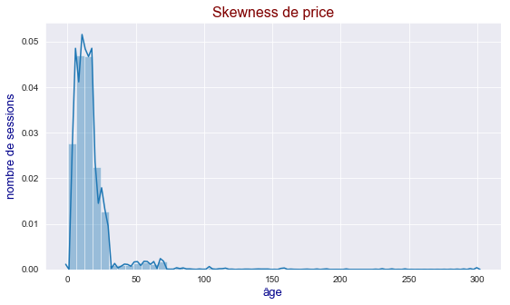

```python
# visualisation du skewness de 'price'
skew = table_clean[['price']].copy()

sns.set_style("darkgrid")
plt.figure(figsize=(9,5))
# graphique
sns.distplot(skew.price)

# titre
plt.title('Skewness de price', fontsize=16, color='maroon')
# labels
plt.xlabel('âge', color='darkblue', size=13)
plt.ylabel('nombre de sessions', color='darkblue', size=13)

plt.savefig('img/Q2/1.2 skew_price.png', dpi=120, bbox_inches='tight')
plt.show()
plt.close()
```

- Il y a très peu d'articles au-delà de 70.00
- Ils sont très concentrés entre le 1e et le 3e quartile

#### 3. [tdm] Courbe le Lorenz et indice Gini de 'price'

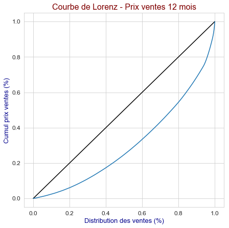

```python
price = [table_clean['price']]

sns.set_style("whitegrid")

d1 = table_clean['price'].values
lorenz = np.cumsum(np.sort(d1)) / d1.sum()
lorenz = np.append([0],lorenz) # La courbe de Lorenz commence à 0

fig, ax = plt.subplots(figsize=[7,7])

# titre
plt.title("Courbe de Lorenz - Prix ventes 12 mois", fontsize=16, color = 'maroon')
# Libellé Abscisse (x)
plt.xticks(size=12)
plt.xlabel("Distribution des ventes (%)", color="darkblue", size=13)
# Libellé Ordonnée (y)
plt.yticks(size=12)
plt.ylabel("Cumul prix ventes (%)", color='darkblue', size=13, rotation=90)
# Ligne d'égalité
ax.plot([0,1], [0,1], color='black')
## Courbe de Lorenz
plt.plot(np.linspace(0,1,len(lorenz)),lorenz,drawstyle='steps-post')

plt.savefig('img/Q2/1.3 lorenz.png', dpi=120, bbox_inches='tight')
plt.show()
plt.close()
```

```python
# indice Gini 'price'
aire_ss_courbe = lorenz.sum()/len(lorenz) # aire sous la courbe de Lorenz
S = 0.5 - aire_ss_courbe # aire entre la 1e bissectrice et la courbe de Lorenz
gini = 2*S

gini
round(gini, 3)
```

```
0.389
```

**Conclusion**

- Avec un **indice Gini = 39%** (même plus proche de 0 que de 1), on commence à sentir une certaine inégalité dans la répartition des ventes
- Si l'on s'en tient à la **médiale**,
  - **50% du cumul** des ventes représente environ **75% de la distribution** des ventes les plus basses
  - **50% du cumul** des ventes représente environ **25% de la distribution** des ventes les plus hautes

### 2. [tdm] Analyse par sexe et par catégories

#### 1. [tdm] Pourcentage hommes/femmes

```python
# Rappel des données
poursex = table_clean[['sex','client_id']]
poursex.count()
```

```
sex          313651
client_id    313651
dtype: int64
```

```python
# compte et ratio par sexe
poursex = poursex.groupby(['sex'])['client_id'].agg(['count'])
m = poursex.loc['m']['count']
f = poursex.loc['f']['count']
poursex = poursex.reset_index()
poursex['p_cent'] =  poursex['count'] / 313651 *100
```

```python
round(poursex, 1)
```

|  | sex | count | p_cent |
| --- | --- | --- | --- |
| 0 | f | 163102 | 52.0 |
| 1 | m | 150549 | 48.0 |

- Il y a 52% de femmes pour 48% d'hommes

#### 2. [tdm] Sexe, âge et catégories

```python
# rappel de la table
age=table_clean[['categ','age','sex']].copy()
age.head(1)
```

|  | categ | age | sex |
| --- | --- | --- | --- |
| 0 | 1 | 69.0 | m |

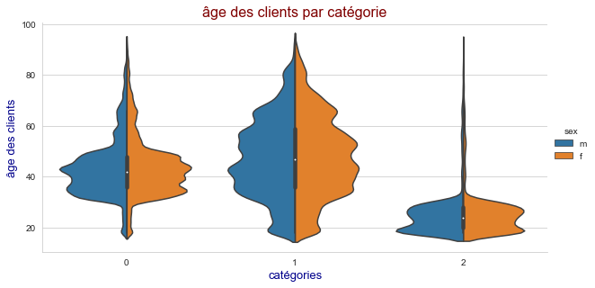

```python
# représentation en violon du prix des produits achetés par catégorie et âge
sns.set_style("whitegrid")

# graphique
sns.catplot(x='categ', y='age', hue='sex',height=4.3, aspect=2,
            kind='violin', split=True, data=age)
# titre
plt.title("âge des clients par catégorie", fontsize=16, color = 'maroon')
# labels
plt.xlabel('catégories', color='darkblue', size=13)
plt.ylabel('âge des clients', color='darkblue', size=13)

plt.savefig('img/Q2/2.2 violon_sex_cat_age.png', dpi=120, bbox_inches='tight')
plt.show()
plt.close()
```

- La répartition par âge et catégories donne une **image quasi symétrique par sexe en fonction de l'âge**

**Par catégorie**

- Une concentration de la **catégorie 0** pour les 30-50 ans, 1e quartile à 35 ans et 3e quartile à 50 ans
- Une répartition plus diffuse de la **catégorie 1** malgré un étrécissement pour les moins de 30 ans, 1e quartile à 35 ans et 3e quartile à 60 ans
- En revanche, elle nous indique une très forte concentration des 18-30 ans pour la **catégorie 2**, 1e quartile à 18 ans et 3e quartile à 30 ans

#### 3. [tdm] Sexe, prix et catégories

```python
# représentation en violon par sexe et dépenses
sexa =table_clean[['categ','price','sex']].copy()

sexa.head(1)
```

|  | categ | price | sex |
| --- | --- | --- | --- |
| 0 | 1 | 16.07 | m |

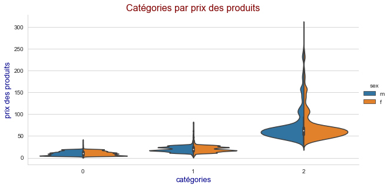

```python
# représentation en violon du prix des produits achetés par catégorie et âge
sns.set_style("whitegrid")

# graphique
sns.catplot(x='categ', y='price', hue='sex',height=4.3, aspect=2,
            kind='violin', split=True, data=sexa)
# titre
plt.title("Catégories par prix des produits", fontsize=16, color = 'maroon')
# labels
plt.xlabel('catégories', color='darkblue', size=13)
plt.ylabel('prix des produits', color='darkblue', size=13)

plt.savefig('img/Q2/2.3 violon_sex_cat_price.png', dpi=120, bbox_inches='tight')
plt.show()
plt.close()
```

- Les catégories semblent être **réparties symétriquement entre hommes et femmes**
- Une recherche de corrélation par sexe semble a priori inutile. Pas d'investigation
- Les violons sont plutôt concentrés, à part pour la catégorie 2 dont le skew est très allongé
- En regardant les espaces interquartiles, on peut observer une possible correlation entre le prix et la catégorie

## 3. [tdm] Produits achetés

#### 1. [tdm] Répartition du prix des produits achetés par âge

```python
# sélection des variables
age=table_clean[['categ','price','age']].copy()
age.head(1)
```

|  | categ | price | age |
| --- | --- | --- | --- |
| 0 | 1 | 16.07 | 69.0 |

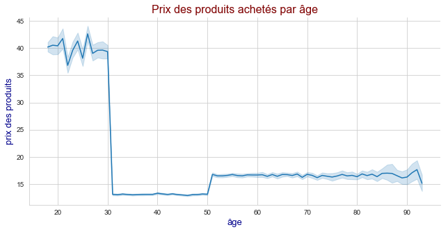

```python
# répartition du prix des produits achetés par âge
sns.set_style("whitegrid")

# graphique
sns.relplot(x="age", y="price", kind="line", height=4.5, aspect=2, data=age)

# titre
plt.title("Prix des produits achetés par âge", fontsize=16, color = 'maroon')
# labels
plt.xlabel('âge', color='darkblue', size=13)
plt.ylabel('prix des produits', color='darkblue', size=13)

plt.savefig('img/Q2/3.1 prod_achetes_age.png', dpi=120, bbox_inches='tight')
plt.show()
plt.close()
```

- Les tranches de prix sont clairement distinctes entre les 18-30 ans, les 30-50 ans et les plus de 50 ans
- pour les 30-50 ans mais aussi pour les 50-70 ans le prix moyen est prédictible avec une grande fiabilité
- pour les 18-30 ans et les +70, l'amplitude de la distribution est plus large

#### 2. [tdm] Répartition du prix des produits achetés par âge et par catégorie

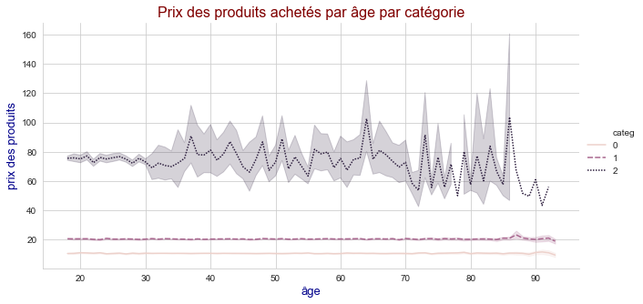

```python
# répartition du CA par âge et par catégorie
sns.set_style("whitegrid")

depenses = table_clean[['age','price','categ']].copy()

# graphique
sns.relplot(x="age", y="price", hue="categ", style="categ",height=4.5, aspect=2,
            kind="line", data=depenses)

# titre
plt.title("Prix des produits achetés par âge par catégorie", fontsize=16, color = 'maroon')
# labels
plt.xlabel('âge', color='darkblue', size=13)
plt.ylabel('prix des produits', color='darkblue', size=13)

plt.savefig('img/Q2/3.2 prod_achetes_age_cat.png', dpi=120, bbox_inches='tight')
plt.show()
plt.close()
```

#### 3. [tdm] Distribution des produits achetés

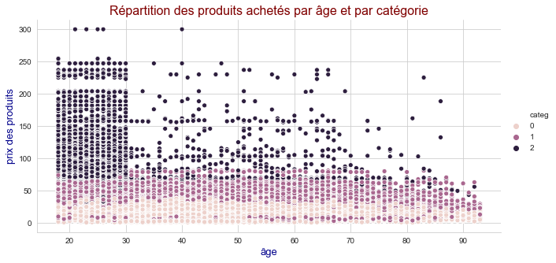

```python
# distribution des produits achetés par âge et catégorie
sns.set_style("whitegrid")

# graphique
sns.relplot(x="age",y="price",hue='categ', height=4.5, aspect=2, data=age)

# titre
plt.title("Répartition des produits achetés par âge et par catégorie", fontsize=16, color = 'maroon')
# labels
plt.xlabel('âge', color='darkblue', size=13)
plt.ylabel('prix des produits', color='darkblue', size=13)

plt.savefig('img/Q2/3.3 prod_cat_age.png', dpi=120, bbox_inches='tight')
plt.show()
plt.close()
```

## 4. [tdm] Sessions

#### 1. [tdm] Nombre de sessions par âge

```python
# groupement par âge, catégorie et nombre de sessions
ses = table_clean[['age','categ','session_id']].copy()
ses = ses.groupby(['age','categ']).session_id.count()
ses = ses.reset_index()
ses.head(1)
```

|  | age | categ | session_id |
| --- | --- | --- | --- |
| 0 | 18.0 | 0 | 1668 |

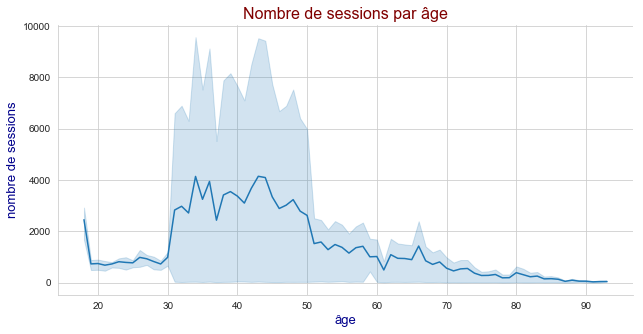

```python
# répartition du nombre de sessions par âge
sns.set_style("whitegrid")

# graphique
sns.relplot(x="age", y="session_id", height=4.5, aspect=2,
            kind="line", data=ses)
# titre
plt.title("Nombre de sessions par âge", fontsize=16, color = 'maroon')
# labels
plt.xlabel('âge', color='darkblue', size=13)
plt.ylabel('nombre de sessions', color='darkblue', size=13)

plt.savefig('img/Q2/4.1 sess_cat_age.png', dpi=120, bbox_inches='tight')
plt.show()
plt.close()
```

- Il y a un pic du nombre de sessions pour les 30-50 ans avec une forte amplitude dans les pratiques
- Pour les 20-30 ans, il y a moins de sessions et des partiques homogènes
- Au-delà de 50 ans, cela décroît lentement avec l'âge
- Il faudra **faire abstraction des 18 ans dans les calculs statistiques oú l'âge est un paramètre**

#### 2. [tdm] Nombre de sessions par âge et par catégorie

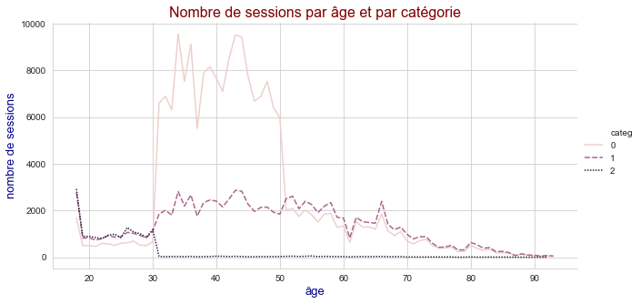

```python
# répartition du nombre de sessions par âge et par catégorie
sns.set_style("whitegrid")

# graphique
sns.relplot(x="age", y="session_id", hue="categ", style="categ",height=4.5, aspect=2,
            kind="line", data=ses)
# titre
plt.title("Nombre de sessions par âge et par catégorie", fontsize=16, color = 'maroon')
# labels
plt.xlabel('âge', color='darkblue', size=13)
plt.ylabel('nombre de sessions', color='darkblue', size=13)


plt.savefig('img/Q2/4.2 sess_cat_age.png', dpi=120, bbox_inches='tight')
plt.show()
plt.close()
```

- Nous retrouvons ce que nous avons déjà identifié dans les graphique en violons
- les 30-50 ans ont un nombre élevé de cessions pour la catégorie 0
- la catégorie 1 est beaucoup plus répartie mais avec un 'ventre' pour les 30-60 ans
- la catégorie 2 est plébicitée par les moins de 30 ans
- Il faudra **faire abstraction des 18 ans dans les calculs statistiques oú l'âge est un paramètre**

## 5. [tdm] Chiffre d'affaires

#### 1. [tdm] Répartition du chiffre d'affaires par âge

```python
# groupement par âge et catégorie avec somme du nombre de sessions
CA = table_clean[['age','categ','price']].copy()
CA = CA.groupby(['age','categ']).price.sum()
CA = CA.reset_index()
# on renomme 'price' en 'CA'
CA.columns = ['age','categ','CA']
CA.head(1)
```

|  | age | categ | CA |
| --- | --- | --- | --- |
| 0 | 18.0 | 0 | 17619.77 |

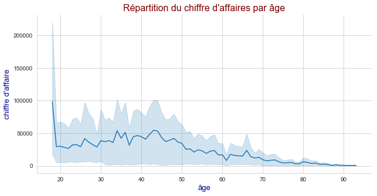

```python
# répartition du CA par âge
sns.set_style("whitegrid")

# graphique
sns.relplot(x="age", y="CA", height=4.5, aspect=2,
            kind="line", data=CA)
# titre
plt.title("Répartition du chiffre d'affaires par âge", fontsize=16, color = 'maroon')
# labels
plt.xlabel('âge', color='darkblue', size=13)
plt.ylabel("chiffre d'affaire", color='darkblue', size=13)

plt.savefig('img/Q2/5.1 CA_age.png', dpi=120, bbox_inches='tight')
plt.show()
plt.close()
```

- Le CA est grossièrement homogène entre 20 et 50 ans (légèrement plus élevé pour les 35-45 ans) puis tend à décroitre ensuite
- Il faudra **faire abstraction des 18 ans dans les calculs statistiques oú l'âge est un paramètre**

#### 2. [tdm] Répartition du chiffre d'affaires par âge et par catégories

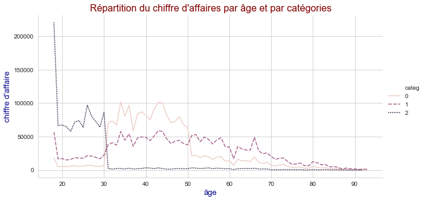

```python
# répartition du nombre du CA par âge et par catégories
sns.set_style("whitegrid")

# graphique
sns.relplot(x="age", y="CA", hue="categ", style="categ",height=4.5, aspect=2,
            kind="line", data=CA)
# titre
plt.title("Répartition du chiffre d'affaires par âge et par catégories", fontsize=16, color = 'maroon')
# labels
plt.xlabel('âge', color='darkblue', size=13)
plt.ylabel("chiffre d'affaire", color='darkblue', size=13)

plt.savefig('img/Q2/5.2 CA_age.png', dpi=120, bbox_inches='tight')
plt.show()
plt.close()
```

- Si le CA entre 20 et 50 ans est globalement homogène, sa distribution est très différente
- pour les 20-30 ans c'est en grande partie dû à l'achat dans la catégorie 2, dans une moindre mesure la catégorie 1 et de façon marginale dans la catégorie 0
- pour les 30-50 ans, c'est la catégorie0 qui est plébicitée et dans une moindre mesure la catégorie 1
- nous avons démontré auparavent que les 30-50 ans des produix à plus bas prix de la cat 0, mais avaient un nombre de sessions plus élevées que les 20-30 ans. Cela explique la relative équivalence de la répartitions du CA pour les 20-30 ans et les 30-50 ans.
- Il faudra **faire abstraction des 18 ans dans les calculs statistiques oú l'âge est un paramètre**

## 6. [tdm] Panier moyen

#### 1. [tdm] Panier moyen par âge

```python
# groupement par âge avec panier moyen par âge
pani = table_clean[['age','categ','price']].copy()
pani = pani.groupby(['age','categ']).price.mean()
pani = pani.reset_index()
# on renomme 'price' en 'panier'
pani.columns = ['age','categ','panier']
pani.head(1)
```

|  | age | categ | panier |
| --- | --- | --- | --- |
| 0 | 18.0 | 0 | 10.563411 |

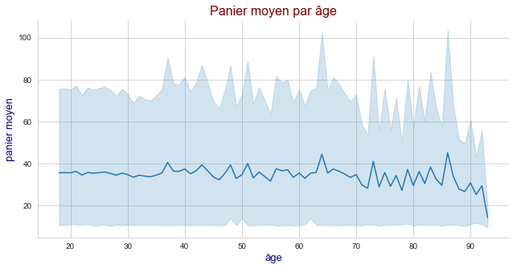

```python
# répartition du panier moyen par âge
sns.set_style("whitegrid")

# graphique
sns.relplot(x="age", y="panier", height=4.5, aspect=2,
            kind="line", data=pani)
# titre
plt.title("Panier moyen par âge", fontsize=16, color = 'maroon')
# labels
plt.xlabel('âge', color='darkblue', size=13)
plt.ylabel("panier moyen", color='darkblue', size=13)

plt.savefig('img/Q2/6.1 pan_age.png', dpi=120, bbox_inches='tight')
plt.show()
plt.close()
```

#### 2. [tdm] Panier moyen par âge et par catégories

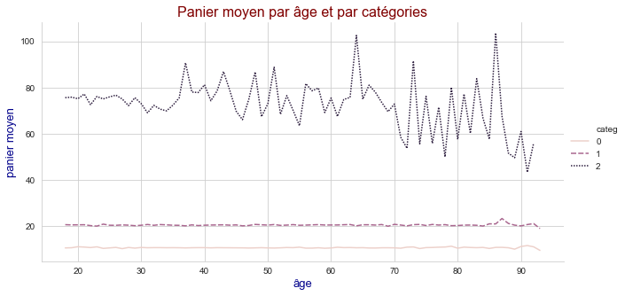

```python
# répartition du nombre du CA par âge et par catégories
sns.set_style("whitegrid")

# graphique
sns.relplot(x="age", y="panier", hue="categ", style="categ",height=4.5, aspect=2,
            kind="line", data=pani)
# titre
plt.title("Panier moyen par âge et par catégories", fontsize=16, color = 'maroon')
# labels
plt.xlabel('âge', color='darkblue', size=13)
plt.ylabel("panier moyen", color='darkblue', size=13)

plt.savefig('img/Q2/6.2 pan_age_cat.png', dpi=120, bbox_inches='tight')
plt.show()
plt.close()
```

- Le panier moyen pour les catégories 0 et 1 est extrêmement prédictible
- Pour la catégorie 2, elle est homogème jusqu'à 30 ans et en dents de scie au-delà.
- cependant il devrait résulter une certaine homogénéité en traçant la ligne de la moyenne ou de la médiane sur cette catégorie

## 7. [tdm] Séries temporelles

#### 1. [tdm] Série temporelle par nombre de sessions et par catégorie

```python
# série temporelle par nombre de sessions
session = table_clean[['timeline','categ','session_id']].copy()
# groupement par timeline, categ et count de price
session = session.groupby(['timeline','categ']).session_id.count()
session = session.reset_index()
session.head(2)
```

|  | timeline | categ | session_id |
| --- | --- | --- | --- |
| 0 | 2021-03 | 0 | 16905 |
| 1 | 2021-03 | 1 | 8542 |

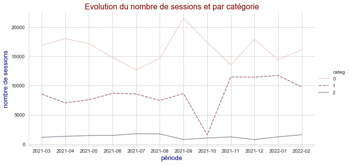

```python
sns.set_style("whitegrid")

# graphique
sns.relplot(x="timeline", y="session_id", hue="categ", style="categ",height=4.5, aspect=2,
            kind="line", data=session)
# titre
plt.title("Evolution du nombre de sessions et par catégorie", fontsize=16, color = 'maroon')
# labels
plt.xlabel('période', color='darkblue', size=13)
plt.ylabel("nombre de sessions", color='darkblue', size=13)

plt.savefig('img/Q2/7.1 sess_age_cat.png', dpi=120, bbox_inches='tight')
plt.show()
plt.close()
```

- Comme observé dans la question 1, il y a un effondrement des sessions de la catégorie 1 due à l'absence de données entre le 2 et le 27 octobre inclus

#### 2. [tdm] Série temporelle par CA et par catégorie

```python
# série temporelle par CA
montant = table_clean[['timeline','categ','price']].copy()
# groupement par timeline, categ et somme de price
montant = montant.groupby(['timeline','categ']).price.sum()
montant = montant.reset_index()
# on renomme 'price' en 'CA'
montant.columns = ['timeline','categ','CA']
montant.head(2)
```

|  | timeline | categ | CA |
| --- | --- | --- | --- |
| 0 | 2021-03 | 0 | 180668.06 |
| 1 | 2021-03 | 1 | 174569.68 |

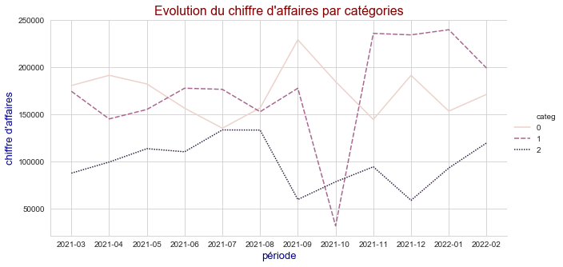

```python
sns.set_style("whitegrid")

# graphique
sns.relplot(x="timeline", y="CA", hue="categ", style="categ",height=4.5, aspect=2,
            kind="line", data=montant)
# titre
plt.title("Evolution du chiffre d'affaires par catégories", fontsize=16, color = 'maroon')
# labels
plt.xlabel('période', color='darkblue', size=13)
plt.ylabel("chiffre d'affaires", color='darkblue', size=13)

plt.savefig('img/Q2/7.2 CA_age_cat.png', dpi=120, bbox_inches='tight')
plt.show()
plt.close()
```

- Comme observé dans la question 1, il y a un effondrement des ventes de la catégorie 1 due à l'absence de données entre le 2 et le 27 octobre inclus